# Record Linkage Presentation

Wednesday, May 27, 2015

## Introduction

The goal of this exercise is to perform record linkage on a simulated dataset. We will explore three methods of linkage:

- Deterministic
- Probabilistic
- Machine Learning

## Generate Data

The first step is to generate the two sets of data that we will attempt to link: a master dataset and an error dataset. We will introduce errors to the error dataset to simulate real world data quality. We will source from a randomly generated dataset and use the `sample_data` function to create the two datasets

```r
dataset <- read.csv("data/generateddata_small.csv")
dataset <- sample_data(dataset, n1 = 500, n2 = 300, overlap = 0.8, error = 0.6)
masterdata <- dataset[[1]]
errordata <- dataset[[2]]
```

## Looking at the Dataset

Let's take a look at the data:

```r
head(masterdata, 5)
```

```
  first_name        last_name gender birth_date        ethnicity       SSN med_number
1     Nathan          Cordova female 11/09/1946            Asian 255383175 6358029309
2       Luke            Quick female  5/28/1952            Asian 125087187 6427424655
3       Jodi          Baldino female  1/22/1971            Asian 516395786 5981030723
4      Guled             Shen   male  4/15/1948 Pacific Islander 143355093 7285462698
5  Viarlenny Picazzo Banuelos   male 10/08/1941            Black 264896375 2283441837
           state        city             address   zip  id
1         Nevada Falanolzace   899 Casjole Grove 68085 848
2   Pennsylvania Gitopupriwa  499 Pihtowi Center 86488 157
3        Georgia Gupoowekuro     196 Pipafof Way 65928 980
4     New Jersey  Fawwelcoja 682 Purima Junction 14597 225
5 South Carolina   Hovruhmij  794 Ruwatibi Plaza 15605 598
```

## Looking at the Dataset

We can get a feel for the data using our own functions. These functions show the percentage of each variable that contain missing data, and the percentage of unique values in each variable.

```r
check_missing_values(errordata)
```

```
 first_name   last_name      gender  birth_date   ethnicity         SSN  med_number       state
0.000000000 0.000000000 0.127090301 0.016722408 0.070234114 0.000000000 0.000000000 0.003344482
       city     address         zip          id
0.020066890 0.000000000 0.040133779 0.000000000
```

```r
check_unique_values(errordata)
```

[output not shown]

## Cleaning the Dataset

### Creating Datasets Used for Deterministic Linkage

The datasets used in this example are fairly clean, but we will make three additional adjustments as examples.

- making sure that dates are formatted correctly

```r
masterdata$birth_date <- as.character(as.Date(masterdata$birth_date, format = "%m/%d/%Y"))
errordata$birth_date <- as.character(as.Date(errordata$birth_date, format = "%m/%d/%Y"))
```

- change character data to lower case

```r
masterdata <- tolower_all(masterdata)
errordata <- tolower_all(errordata)
```

- upon examining the data, we notice that some last names contain '-' and ' '.

```r
masterdata$last_name <- sub("-", "", masterdata$last_name)
errordata$last_name <- sub("-", "", errordata$last_name)
masterdata$last_name <- gsub("\\s", "", masterdata$last_name)
errordata$last_name <- gsub("\\s", "", errordata$last_name)
```

## Cleaning the Dataset

### Creating Datasets Used for Deterministic Linkage

Before we continue, we can check to see if the two sets have matching variable names so that we can perform linkage.

```r
sort(names(masterdata))
```

```
 [1] "address"    "birth_date" "city"       "ethnicity"  "first_name" "gender"     "id"
 [8] "last_name"  "med_number" "SSN"        "state"      "zip"
```

```r
sort(names(errordata))
```

```
 [1] "address"    "birth_date" "city"       "ethnicity"  "first_name" "gender"     "id"
 [8] "last_name"  "med_number" "SSN"        "state"      "zip"
```

## Deterministic Linkage

We will create deterministic links by creating a series of keys. Each key is a character string created by concatenating the values from the relevant variables. Each successive key has one variable dropped, going from most specific to least specific.

Here's a sample of the code:

- Adding keys to `masterdata` and `errordata`

```r
# adding keys
masterdata$key9 <- paste(masterdata$address, masterdata$birth_date, masterdata$city, masterdata$ethnicity,
    masterdata$first_name, masterdata$gender, masterdata$last_name, masterdata$med_number, masterdata$SSN,
    masterdata$state, masterdata$zip, sep = ":")

errordata$key9 <- paste(errordata$address, errordata$birth_date, errordata$city, errordata$ethnicity,
    errordata$first_name, errordata$gender, errordata$last_name, errordata$med_number, errordata$SSN,
    errordata$state, errordata$zip, sep = ":")
```

## Deterministic Linkage

- Merging records from masterdata and errordata that has exact matching for key9

```r
k9 <- merge(masterdata, errordata, by.x = "key9", by.y = "key9")
```

- Creating subset of unmatched records for further matching by subsequent keys

Note: the SSN is used here as a proxy for a unique identifier, since there are no duplicated values for SSN in the dataset.

```r
master.9 <- subset(masterdata, subset = !(masterdata$SSN %in% k9$SSN.x))
error.9 <- subset(errordata, subset = !(errordata$SSN %in% k9$SSN.x))
table(k9$SSN.x)  #check for duplicates
```

- After matching has been completed, remove extra variables for final output

```r
k9 <- remove.vars(k9, c("key9", "key1.x", "key2.x", "key3.x", "key4.x", "key5.x", "key6.x", "key7.x",
    "key8.x", "key1.y", "key2.y", "key3.y", "key4.y", "key5.y", "key6.y", "key7.y", "key8.y"))
k9$key <- "9"
```

## Deterministic Linkage

Key 1 - 8 follow the same process as demonstrated for key 9. For each subsequent key, one or more variables are removed in the order of the frequency of values.

As we have seen before, the percentage of unique values in each variable is:

```r
check_unique_values(errordata)
```

```
first_name  last_name     gender birth_date  ethnicity        SSN med_number      state
0.90635452 0.91304348 0.01003344 0.93645485 0.02006689 1.00000000 1.00000000 0.17056856
      city    address        zip         id
0.98327759 1.00000000 0.95652174 1.00000000
```

Therefore, variables are removed in the order of: gender, ethnicity, state, first name, last name, birth date, zip, city, and address.

## Deterministic Linkage

Let's take a look at the matching result:

```
  first_name.x last_name.x gender.x birth_date.x     ethnicity.x     SSN.x med_number.x
1     angelina      poitra   female   1967-11-17           black 973366913   4894796567
2      kaitlyn       young   female   1964-09-01 native american 276085847   3385487046
3        ayush      morgan     male   1946-12-25           asian 693257025   3276559286
     state.x      city.x           address.x zip.x id.x first_name.y last_name.y gender.y
1      idaho dahonicutad 1018 ukilsuju trail 97088  152     angelina      poitra   female
2 new jersey  orotedinos  1049 hodakid plaza 45026  878      kaitlyn       young   female
3   new york  jovejomcat 1079 ranubar street 73081  308        ayush      morgan     male
  birth_date.y     ethnicity.y     SSN.y med_number.y    state.y      city.y           address.y
1   1967-11-17           black 973366913   4894796567      idaho dahonicutad 1018 ukilsuju trail
2   1964-09-01 native american 276085847   3385487046 new jersey  orotedinos  1049 hodakid plaza
3   1946-12-25           asian 693257025   3276559286   new york  jovejomcat 1079 ranubar street
  zip.y id.y key
1 97088  152   9
2 45026  878   9
3 73081  308   9
```

## Cleaning the Dataset

### Creating Datasets Used for probabilistic Linkage

For probabilistic linkage, we make two additional adjustments to the dataet:

- Separating the birth date into three separate fields, year, month, and day:

```r
masterdata$byear <- substr(masterdata$birth_date, 1, 4)
masterdata$bmonth <- substr(masterdata$birth_date, 6, 7)
masterdata$bday <- substr(masterdata$birth_date, 9, 10)
masterdata$birth_date <- NULL

errordata$byear <- substr(errordata$birth_date, 1, 4)
errordata$bmonth <- substr(errordata$birth_date, 6, 7)
errordata$bday <- substr(errordata$birth_date, 9, 10)
errordata$birth_date <- NULL
```

- Creating a new variable for initials, we will use this as a blocking variable:

```r
masterdata$initial <- paste0(substr(masterdata$first_name, 1, 1), substr(masterdata$last_name, 1,
    1))
errordata$initial <- paste0(substr(errordata$first_name, 1, 1), substr(errordata$last_name, 1, 1))
```

## Probabilistic Linkage

We perform probabilistic Linkage through using the `RecordLinkage` package in R.

The first step is to create record pairs. Two datasets of size `n` and `m` will produce `n x m` number of record pairs.

```r
rpairs <- compare.linkage(errordata, masterdata, exclude = c('id'),
                          identity1 = errordata$id, identity2 = masterdata$id)
```

The next step is to calculate the probabilistic weights assigned to each matching and non-matching variables. There are many algorithms for this, such as the EM algorithm and the EPI algorithm. In this example, we'll use the EPI method.

```r
rpairs <- epiWeights(rpairs)
```

## Probabilistic Linkage

let's take a look at the weight distribution:

```r
summary(rpairs)
```

```
Linkage Data Set

299 records in data set 1
500 records in data set 2
149500 record pairs

240 matches
149260 non-matches
0 pairs with unknown status


Weight distribution:

  [0,0.05] (0.05,0.1] (0.1,0.15] (0.15,0.2] (0.2,0.25] (0.25,0.3] (0.3,0.35] (0.35,0.4]
    133551      14404       1220         69         15          3          1          5
(0.4,0.45] (0.45,0.5] (0.5,0.55] (0.55,0.6] (0.6,0.65] (0.65,0.7] (0.7,0.75] (0.75,0.8]
         8         20         16         20         20         22         13         13
(0.8,0.85] (0.85,0.9] (0.9,0.95]   (0.95,1]
         3          0          1         96
```

## Probabilistic Linkage

Looking at the weight distribution, we can choose a few potential thresholds and manually examine the record pairs. We want to minimize the number of false positives, while still having a reasonable number of possible links that we can manually review.

For example, the 0.45-0.5 range seems to be a good candidate for the upper threshold.

```r
tail(getPairs(rpairs, 0.5, 0.45))
```

```
    id  first_name last_name gender       ethnicity       SSN med_number     state         city
55 115 ngatchanial     adams   male            <NA> 927330790 9430472208  new york  tubarukkuzo
56 405   nathanial     adams   male native american 927330790 4930472208  missouri codoaburwono
57
58 131          ty acokhartr   male           white 745353022 1443497156 louisiana    uhamifilo
59 216          ty  lockhart   male           white 745353022 1443494156 louisiana    uhamifilo
60
              address   zip  id byear bmonth bday initial    Weight
55    1351 epajiv key 40897  46  1914     04   02      na
56    1351 epajiv key 40807  46  1914     02   26      na 0.4516813
57
58  17 jacikif square 57857 441  1953     06   12      ta
59 17 jacikif terrace 57853 441  1953     07   21      tl 0.4510020
60
```

## Probabilistic Linkage

It seems like in the 0.3-0.35 range the pairs start to look like unlikely matches. We'll use 0.3 as the lower cutoff for the purpose of the example. We'd probably go even lower in practice.

```r
head(getPairs(rpairs, 0.35, 0.3))
```

```
   id first_name last_name gender        ethnicity       SSN med_number         state
1 212    dilliam   fxentes   male pacific islander 770327842 7927114443 new hampshire
2  29    william   fuentes   male pacific islander 770327842 9727114443      kentucky
3
          city             address   zip  id byear bmonth bday initial    Weight
1 buviojatewud      725 jeveci jct 15943 260  1970     04   07      df
2 buviojatewud 725 jeveci turnpike 15943 260  1963     07   04      wf 0.3266525
3
```

```r
rpairs <- epiClassify(rpairs, 0.45, 0.3)
```

## Probabilistic Linkage

Since the number of record pairs can become very large, it can get expensive to compute. One solution is to introduce a blocking variable, and only pairs that match on the blocking variable are compared.

```r
rpairsb <- compare.linkage(errordata, masterdata, blockfld = c('initial'),
                           strcmp = c('first_name','last_name','state','city','address'),
                           exclude ='id', identity1 = errordata$id, identity2 = masterdata$id)
rpairsb <- epiWeights(rpairsb)
rpairsb <- epiClassify(rpairsb,0.55,0.45)
```

## Probabilistic Linkage

To account for slight variations in string values, we can incorporate similar matching to the weights calculations. This is done through string comparison functions. The default method is the Jaro-Winkler.

```r
rpairs2 <- compare.linkage(errordata, masterdata, strcmp = c('first_name', 'last_name',
                                                             'state', 'city', 'address'),
                          exclude ='id', identity1 = errordata$id, identity2 = masterdata$id)
rpairs2 <- epiWeights(rpairs2)
```

To compare with the initial linkage result without string similarity, we use the same upper threshold of 0.45 to classify pairs as links.

```r
rpairs2 <- epiClassify(rpairs2, 0.45)
```

## Probabilistic Linkage

If we didn't know the identity of the records, how can we check and improve the accuracy of the links?

Suppose we had set a lower threshold:

```r
rpairs3 <- epiClassify(rpairs3, 0.6, 0.4)
links <- with(rpairs3, {
    pairs[prediction == "L", ]
})
possible_links <- with(rpairs3, {
    pairs[prediction == "P", ]
})
length(possible_links$id1)
```

```
[1] 43
```

```r
length(unique(possible_links$id1))
```

```
[1] 42
```

We can see that there are duplicates in possible_links. We also expect a larger number of possible links due to the broader range of weight thresholds.

## Probabilistic Linkage

In this situation, we can utilize additional techniques to improve linkage results given our knowledge of the dataset.

For example, we can make adjustments to the weights based on characteristics of the data. We know that the first 3 digits of zip codes tend to be more accurate than the entire zip code value. Therefore, we can give more weight to a pair if the first 3 digits of zip agree and then reclassify.

```r
unknown <- which(rpairs3$Wdata < 0.6 & rpairs3$Wdata >= 0.4)
for (i in unknown) {
    p1 <- errordata[rpairs3$pairs$id1[i], ]
    p2 <- masterdata[rpairs3$pairs$id2[i], ]
    zip <- as.numeric(substr(as.character(p1$zip), 1, 3)) == as.numeric(substr(as.character(p2$zip),
        1, 3))
    if (!is.na(zip) && zip == T)
        rpairs3$Wdata[i] <- min(1, rpairs3$Wdata[i] + 0.1)
}

rpairs3 <- epiClassify(rpairs3, 0.6, 0.4)
```

## Probabilistic Linkage

We can get rid of multiple matches based on certain rules. For example, we'll take the pair that have the most similar SSN value in the case of multiple matches.

```r
multlinks <- as.numeric(names(Filter(isTRUE, table(possible_links$id1) > 1)))
lab <- possible_links[possible_links$id1 %in% multlinks, ]
data <- errordata[lab$id1, ]
rec <- masterdata[lab$id2, ]
choice <- which.max(levenshteinSim(as.character(data$SSN), as.character(rec$SSN)))
replace <- as.numeric(rownames(lab)[setdiff(seq(nrow(lab)), choice)])
rpairs3$Wdata[replace] <- 0
rpairs3 <- epiClassify(rpairs3, 0.6, 0.4)
```

## Probabilistic Linkge

### Machine Learning Method

We will now look at using supervised learning to link datasets.

First, we need to get a subset of the data:

```r
set.seed(426)
smasterdata <- masterdata[sample(1:nrow(masterdata), 200), ]
serrordata <- errordata[errordata$id %in% smasterdata$id, ]
```

Then, we create the record pairs as before. In this example, we use the fellegi-sunter method of weight calculations:

```r
samplerpairs <- compare.linkage(serrordata, smasterdata, exclude = "id", identity1 = serrordata[,
    "id"], identity2 = smasterdata[, "id"])
samplerpairs <- fsWeights(samplerpairs)
```

We get a minimal training set that has each comparison pattern represented at least 3 times.

```r
sampletrain <- getMinimalTrain(samplerpairs, nEx = 3)
```

## Probabilistic Linkge

### Machine Learning Method

Let's take a look at the weight distribution of true links and true non-links:

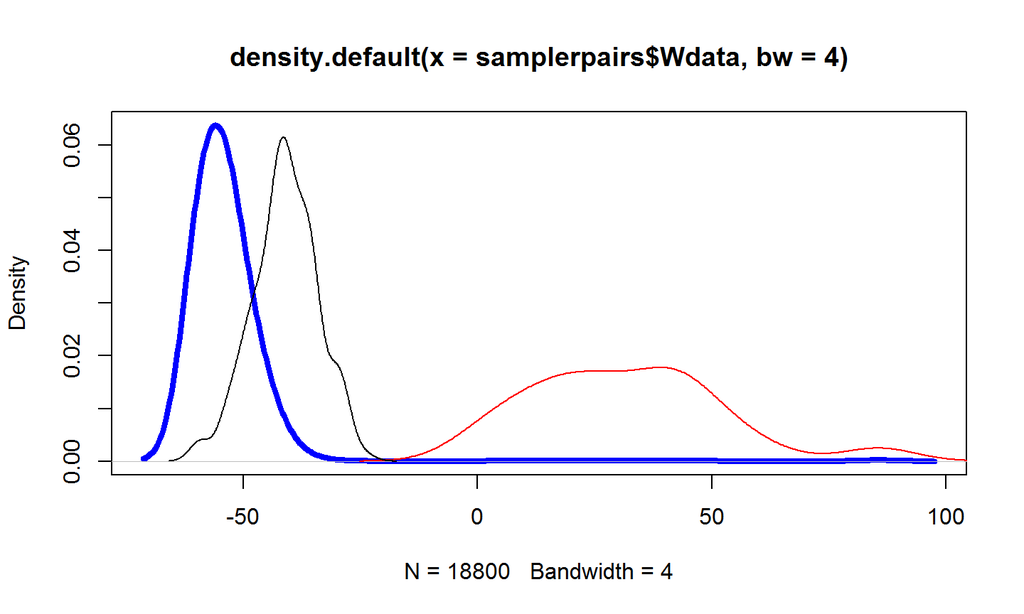

## Probabilistic Linkge

### Machine Learning Method

Since we already have the identity within the dataset, we can now train a classifier. If we did not know the identity of the records, we would manually identify true matches in the training set.

```r
samplemodel <- trainSupv(sampletrain, method = "bagging")
```

Now, we can apply this model to the entire dataset. Notice that the supervised learning approach does not require us to select a threshold.

```r
rpairsml <- compare.linkage(errordata, masterdata, exclude = "id", identity1 = errordata[, "id"],
    identity2 = masterdata[, "id"])
rpairsml <- fsWeights(rpairsml)
resultml <- classifySupv(samplemodel, newdata = rpairsml)
```

## Testing

Now, let's take a look at how the different methods performed.

## Testing - Deterministic

The deterministic method found 143 matches, with 100 percent of the matches being true links.

We can also see how many matches were found at each key:

```
Source: local data frame [5 x 2]

  key count
1   1    24
2   2    14
3   3     8
4   4     1
5   9    96
```

The datasets contain 240 true matches, so the deterministic method, although accurate, has missed 97 links, or 40.42 percent.

## Testing - Probabilistic I

At thresholds of of 0.45 and 0.3, probabilistic linkage without blocking or string comparisons yielded the following results:

```r
getTable(rpairs)
```

```
           classification
true status      N      P      L
      FALSE 149260      0      0
      TRUE       2     14    224
```

## Testing - Probabilistic II

```r
getTable(rpairsb)
```

```
           classification
true status   N   P   L
      FALSE 497   1   0
      TRUE    1   0 196
```

There are a total of 240 true matches between the two datasets. However, with blocking, we can see that there are only 197 matches. Although using a blocking variable significantly sped up the computations, we have lost 18% of links due to blocking.

## Testing - Probabilistic III

At thresholds of of 0.45, probabilistic linkage without blocking and with string comparison on variables `first_name, last_name, state, city, address` yielded the following results:

```r
getTable(rpairs2)
```

```
           classification
true status      N      P      L
      FALSE 149259      0      1
      TRUE       1      0    239
```

Comparing this to the result without string comparison, we can see that we were able to find more true matches at the same thresholds.

```r
getTable(rpairs)
```

```
           classification
true status      N      P      L
      FALSE 149260      0      0
      TRUE       2     14    224
```

## Testing - Probabilistic IV

At thresholds of of 0.6 and 0.4, probabilistic linkage without blocking and with string comparison on variables `first_name, last_name, state, city, address`, as well as additional adjustments yielded the following results:

```r
getTable(rpairs3)
```

```
           classification
true status      N      P      L
      FALSE 149233     27      0
      TRUE       0      6    234
```

Compare this to the result prior to adjustments, we can see that we were able to reduce the number of possible links with good accuracy.

```r
before.adjustment
```

```
           classification
true status      N      P      L
      FALSE 149232     28      0
      TRUE       0     15    225
```

## Testing - Probabilistic V

With the classifier trained from a sample dataset, we get the following result:

```r
getTable(resultml)
```

```
           classification
true status      N      P      L
      FALSE 149259      0      1
      TRUE       2      0    238
```

## Summary

With this record linkage example, we can see how different methods performed on a simulated dataset.

Compared to the probabilistic methods, the deterministic method resulted in great accuracy, but at the expense of missing a large percentage of true links. This shows that the deterministic method worked very well for the subset of the data that had high quality and few errors, but it was not able to pick up links with more variations in the variables.

Within the probabilistic methods, we can see that selecting the appropriate thresholds is essential to the linkage performance. We have also seen that using a blocking variable can significantly reduce the number of true links found, therefore it is important to select a high quality blocking variable or use a multi-pass approach.

In addition, additional techniques such as using string similarity comparison and guided weight adjustments can reduce the number of possible links and lead to better performance.

Lastly, as seen from its impressive result, machine learning represents a good alternative if appropriate sample data and match status can be obtained.